# Настройка безопасного удалённого доступа по SSH

Лабораторная работа №11

Элсаиед Адел

Российский университет дружбы народов, Москва, Россия

6 января 2026

# Цели и задачи работы

## Цель лабораторной работы

Приобретение практических навыков по настройке безопасного удалённого доступа к серверу с помощью протокола SSH.

# Выполнение работы

## Запрет доступа по SSH для пользователя root

На сервере выполнен запрет удалённого входа для root с помощью параметра `PermitRootLogin no`. Повторная попытка входа фиксируется в журналах и завершается отказом на стадии аутентификации.

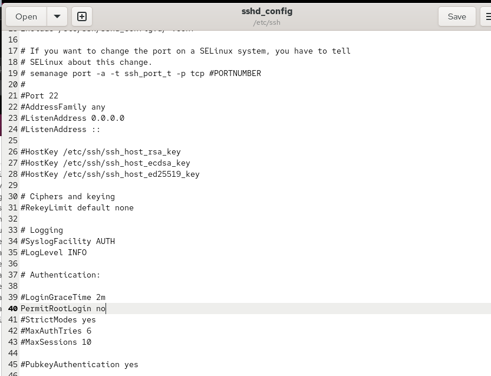

Запрет входа root через PermitRootLogin no

## Контроль попыток входа root в журнале

При попытке SSH-входа под root на сервере регистрируются события отказа/завершения сессии, что подтверждает применение настроек безопасности.

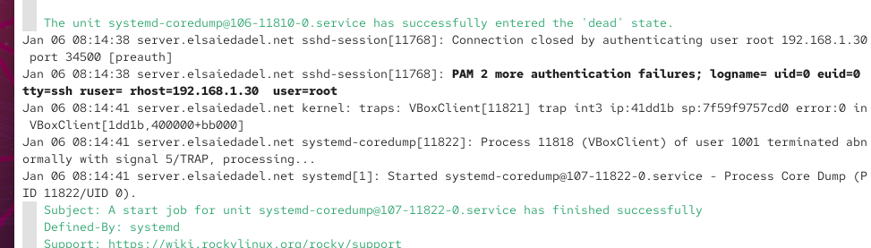

Попытка входа root после запрета

## Ограничение списка пользователей (AllowUsers)

Для контроля удалённого доступа задан список разрешённых пользователей. При включении `AllowUsers vagrant` подключения прочих пользователей отклоняются.

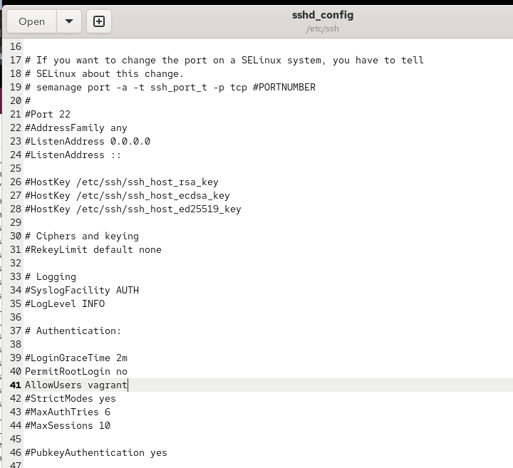

Ограничение доступа по SSH параметром AllowUsers

## Восстановление доступа добавлением пользователя в AllowUsers

Для разрешения подключения добавлен пользователь `elsaiedadel` в список. После перезапуска sshd удалённый вход становится доступен.

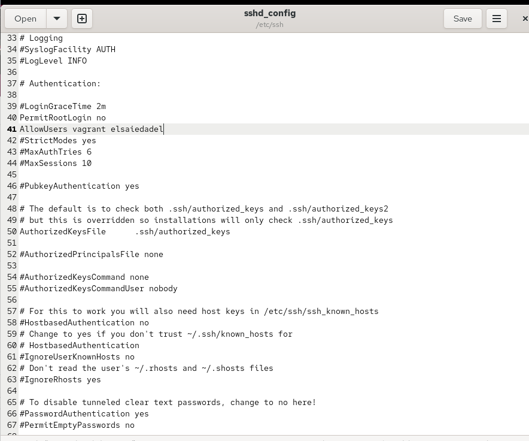

Добавление пользователя в AllowUsers

## Перенос SSH на порт 2022: корректная конфигурация

Для работы SSH на порту 2022 в конфигурации заданы отдельные директивы `Port 22` и `Port 2022`, что обеспечивает одновременное прослушивание двух портов.

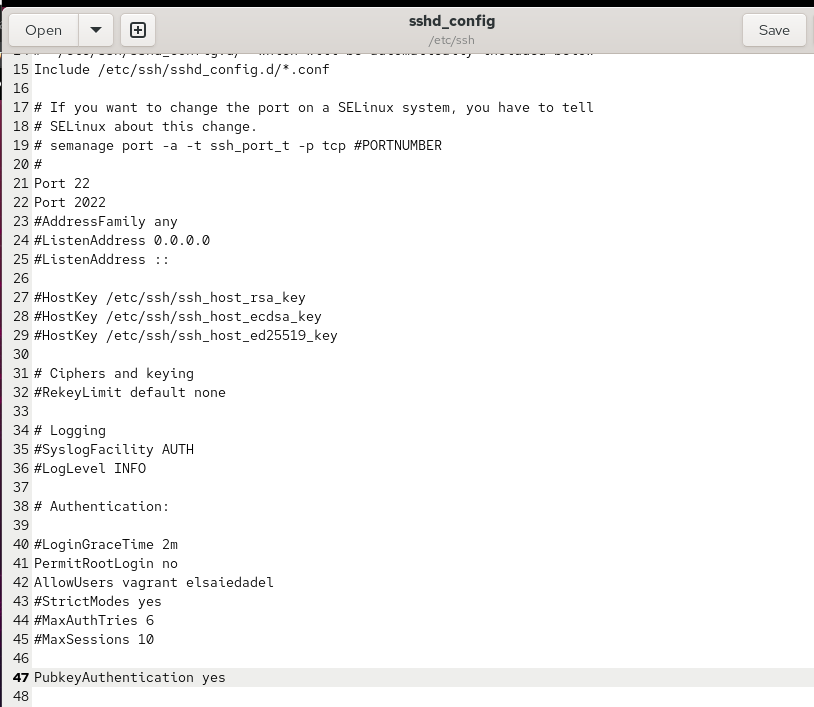

Настройка Port 22 и Port 2022 в sshd_config

## SELinux и firewall для порта 2022

Выполнена настройка SELinux для разрешения контекста `ssh_port_t` на 2022 и открытие `2022/tcp` в межсетевом экране. После исправления конфигурации sshd успешно запущен и слушает порт 2022.

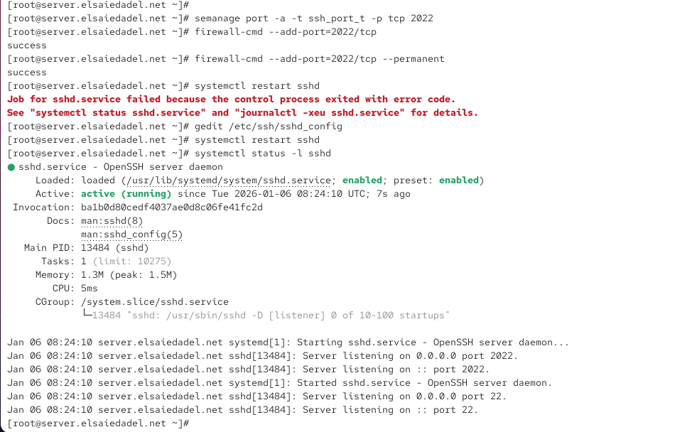

Настройка SELinux и firewalld и успешный запуск sshd

## Проверка подключений по портам 22 и 2022

С клиента подтверждено, что соединение устанавливается как по порту 22 (по умолчанию), так и по порту 2022 при явном указании параметров подключения.

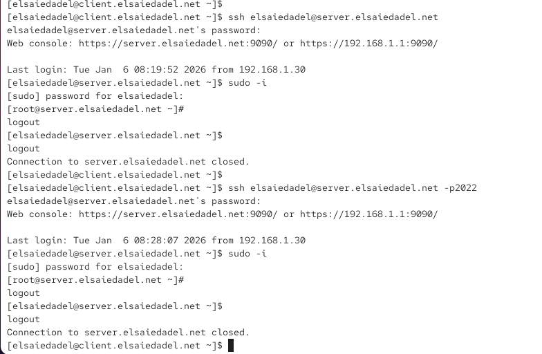

Проверка SSH-подключения на портах 22 и 2022

## Аутентификация по ключу (PubkeyAuthentication)

На сервере включена аутентификация по ключу. На клиенте создана пара ключей и открытый ключ установлен на сервер, после чего вход выполняется без запроса пароля.

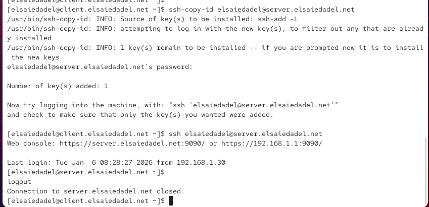

Копирование ключа на сервер и вход без пароля

## SSH-туннель: перенаправление порта 8080 на 80

Организовано перенаправление: локальный порт 8080 обслуживается процессом SSH и проксирует доступ к удалённому сервису на порту 80. Состояние подтверждается появлением локального LISTEN и активного SSH-соединения.

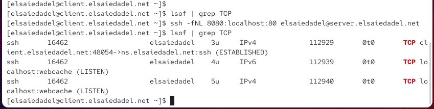

TCP-сокеты до/после создания туннеля

## Проверка туннеля в браузере

При открытии `localhost:8080` на клиенте отображается приветственная страница, что подтверждает корректную работу туннеля и перенаправления.

[figure not shown]

Страница Welcome через localhost:8080

## Запуск удалённых консольных команд через SSH

Проверен запуск команд на сервере без интерактивной сессии: получение имени хоста, просмотр файлов и проверка почты. Это демонстрирует применение SSH как инструмента удалённого администрирования.

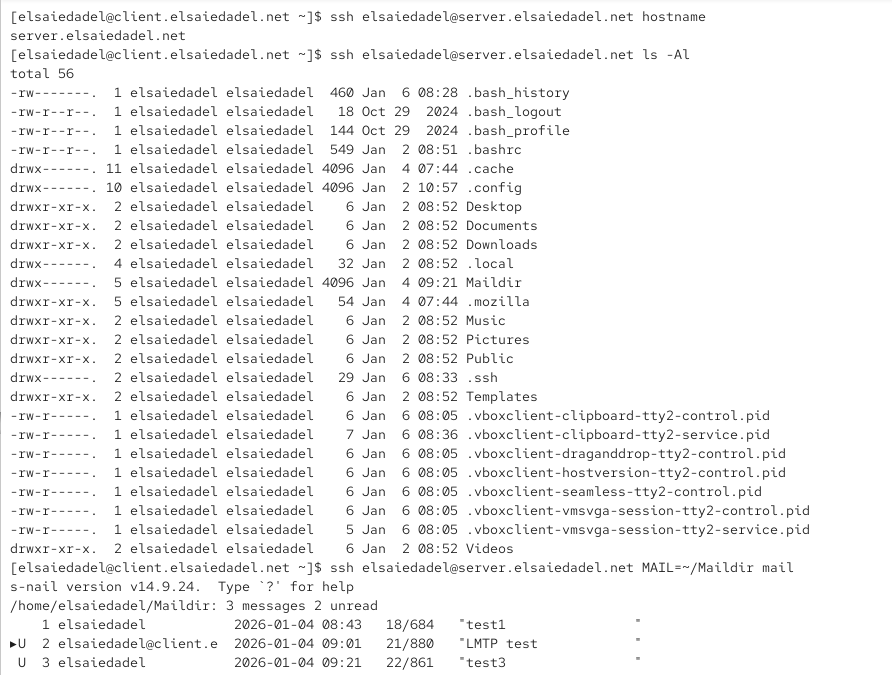

Удалённый запуск hostname, ls и mail

## X11 Forwarding: попытка запуска графического приложения

Разрешено `X11Forwarding yes`, затем выполнена попытка удалённого запуска Firefox. На клиенте получена ошибка, связанная с отсутствием DISPLAY и невозможностью X11-перенаправления, что указывает на необходимость настроенного X-сервера на стороне клиента.

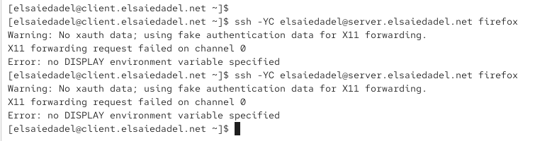

Ошибка X11: отсутствует DISPLAY

## Автоматизация настроек: provisioning-скрипт ssh.sh

Подготовлен скрипт, который копирует эталонную конфигурацию SSH, восстанавливает контексты SELinux, настраивает firewall для 2022 и перезапускает sshd. Это обеспечивает воспроизводимое применение настроек при запуске ВМ.

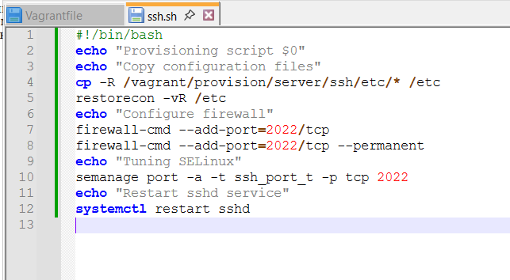

Provisioning-скрипт ssh.sh

# Выводы

## Вывод

В ходе работы выполнена настройка безопасного SSH-доступа: запрещён вход root, ограничены пользователи, настроены ключи, выполнен перенос SSH на порт 2022 с поддержкой SELinux и firewall, проверены туннели и удалённый запуск команд. Подготовлен provisioning-скрипт для автоматизации конфигурации SSH в среде виртуализации.